# Презентация по лабораторной работе №9

Дисциплина: Операционные системы

Шошина Е.А.

Российский университет дружбы народов, Москва, Россия

9 апреля 2023

# Информация

## Докладчик

- Шошина Евгения Александровна
- группа: НКАбд-03-22
- студент факультета физико-математических и естественных наук
- Российский университет дружбы народов
- 1132229532@pfur.ru
- https://EAShoshina.github.io/ru/

# Вводная часть

## Цель

Познакомиться с операционной системой Linux. Получить практические навыки работы с редактором Emacs.

## Задачи

1. Ознакомиться с теоретическим материалом.
2. Ознакомиться с редактором emacs.
3. Выполнить упражнения.
4. Ответить на контрольные вопросы.

## Задачи

1. Открыть emacs.
2. Создать файл lab07.sh с помощью комбинации Ctrl-x Ctrl-f (C-x C-f).
3. Наберите текст, который дан.
4. Сохранить файл с помощью комбинации Ctrl-x Ctrl-s (C-x C-s).

## 5. Проделать с текстом стандартные процедуры редактирования, каждое действие должно осуществляться комбинацией клавиш.

- 5.1. Вырезать одной командой целую строку (С-k).
- 5.2. Вставить эту строку в конец файла (C-y). 5.3. Выделить область текста (C-space).
- 5.4. Скопировать область в буфер обмена (M-w).
- 5.5. Вставить область в конец файла.
- 5.6. Вновь выделить эту область и на этот раз вырезать её (C-w).
- 5.7. Отмените последнее действие (C-/).

## 6. Научитесь использовать команды по перемещению курсора.

- 6.1. Переместите курсор в начало строки (C-a).
- 6.2. Переместите курсор в конец строки (C-e).
- 6.3. Переместите курсор в начало буфера (M-<).
- 6.4. Переместите курсор в конец буфера (M->).

## 7. Управление буферами.

- 7.1. Вывести список активных буферов на экран (C-x C-b).
- 7.2. Переместитесь во вновь открытое окно (C-x) o со списком открытых буферов и переключитесь на другой буфер.
- 7.3. Закройте это окно (C-x 0).
- 7.4. Теперь вновь переключайтесь между буферами, но уже без вывода их списка на экран (C-x b).

## 8. Управление окнами.

- 8.1. Поделите фрейм на 4 части: разделите фрейм на два окна по вертикали (C-x 3), а затем каждое из этих окон на две части по горизонтали (C-x 2).
- 8.2. В каждом из четырёх созданных окон откройте новый буфер (файл) и введите несколько строк текста.

## 9. Режим поиска

- 9.1. Переключитесь в режим поиска (C-s) и найдите несколько слов, присутствующих в тексте.
- 9.2. Переключайтесь между результатами поиска, нажимая C-s.
- 9.3. Выйдите из режима поиска, нажав C-g.
- 9.4. Перейдите в режим поиска и замены (M-%), введите текст, который следует найти и заменить, нажмите Enter , затем введите текст для замены. После того как будут подсвечены результаты поиска, нажмите ! для подтверждения замены.
- 9.5. Испробуйте другой режим поиска, нажав M-s o. Объясните, чем он отличается от обычного режима?

# Теоретическое введение

## Emacs

Emacs — один из наиболее мощных и широко распространённых редакторов, используемых в мире UNIX. По популярности он соперничает с редактором vi и его клонами. В зависимости от ситуации, Emacs может быть: - текстовым редактором; - программой для чтения почты и новостей Usenet; - интегрированной средой разработки (IDE); - операционной системой;

## Emacs

Всё это разнообразие достигается благодаря архитектуре Emacs, которая позволяет расширять возможности редактора при помощи языка Emacs Lisp. На языке C написаны лишь самые базовые и низкоуровневые части Emacs, включая полнофункциональный интерпретатор языка Lisp. Таким образом, Emacs имеет встроенный язык программирования, который может использоваться для настройки, расширения и изменения поведения редактора. В действительности, большая часть того редактора, с которым пользователи Emacs работают в наши дни, написана на языке Lisp. Первая версия редактора Emacs была написана в 70-х годах 20-го столетия Richard Stallman (Ричардом Столманом) как набор макросов для редактора TECO. В дальнейшем, уже будучи основателем Фонда Свободного программного обеспечения Free Software Foundation и проекта GNU, Stallman разработал GNU Emacs в развитие оригинального Emacs и до сих пор сопровождает эту программу. Emacs является одним из старейших редакторов. Он использовался тысячами программистов на протяжении последних 20 с лишним лет, для него создано много дополнительных пакетов расширений. Эти дополнения позволяют делать с помощью Emacs такие вещи, которые Stallman , вероятно, даже не считал возможными в начале своей работы над редактором. [1]

# Выполнение лабораторной работы

## 1. Открыть emacs.

[figure not shown]

Редактор Emacs

##2. Создать файл lab07.sh с помощью комбинации Ctrl-x Ctrl-f (C-x C-f).

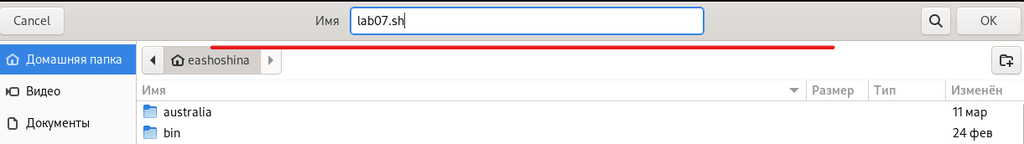

##3. Наберите текст, который дан. 4. Сохранить файл с помощью комбинации Ctrl-x Ctrl-s (C-x C-s).

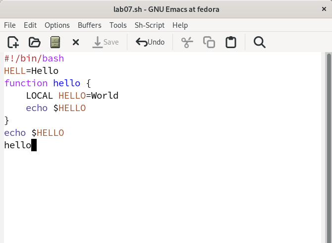

Текст в редакторе

# 5. Проделать с текстом стандартные процедуры редактирования, каждое действие должно осуществляться комбинацией клавиш.

## 5.1. Вырезать одной командой целую строку (С-k).

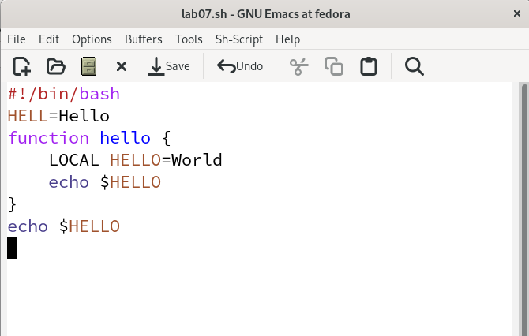

Вырезание строчки

## 5.2. Вставить эту строку в конец файла (C-y).

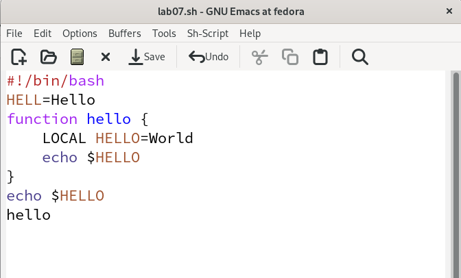

Вставка строчки в конец файла

## 5.3. Выделить область текста (C-space).

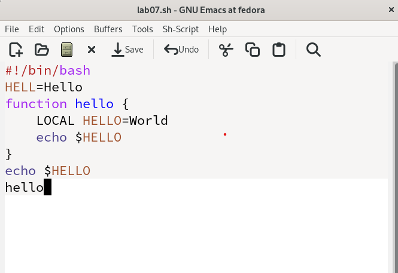

Выделение области текста

## 5.4. Скопировать область в буфер обмена (M-w). 5.5. Вставить область в конец файла.

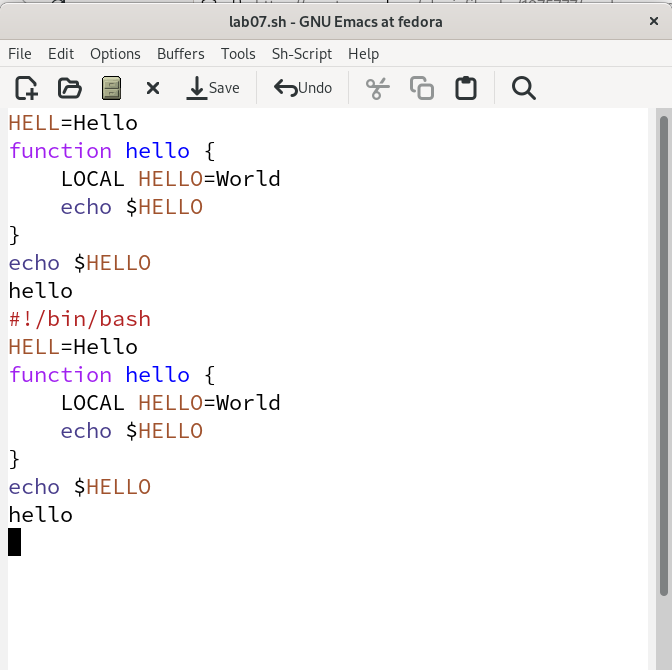

Вставка скопированной области в конец файла

## 5.6. Вновь выделить эту область и на этот раз вырезать её (C-w).

[figure not shown]

Вырезание области текста

## 5.7. Отмените последнее действие (C-/).

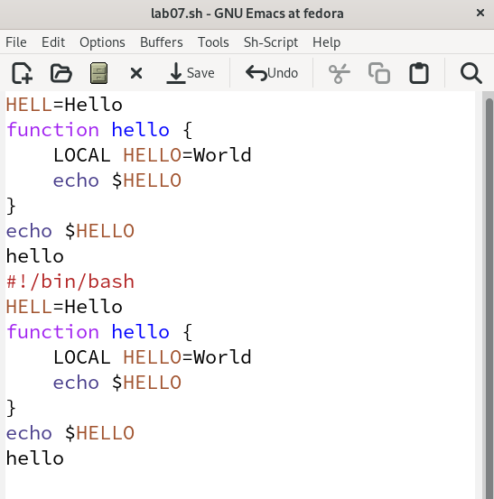

Отмена последнего действия

# 6. Научитесь использовать команды по перемещению курсора.

## 6.1. Переместите курсор в начало строки (C-a). 6.2. Переместите курсор в конец строки (C-e). 6.3. Переместите курсор в начало буфера (M-<). 6.4. Переместите курсор в конец буфера (M->).

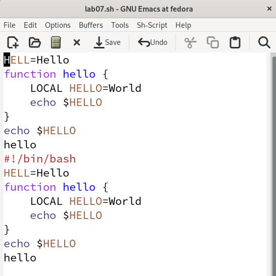

Команды по перемещению курсора

# 7. Управление буферами.

## 7.1. Вывести список активных буферов на экран (C-x C-b).

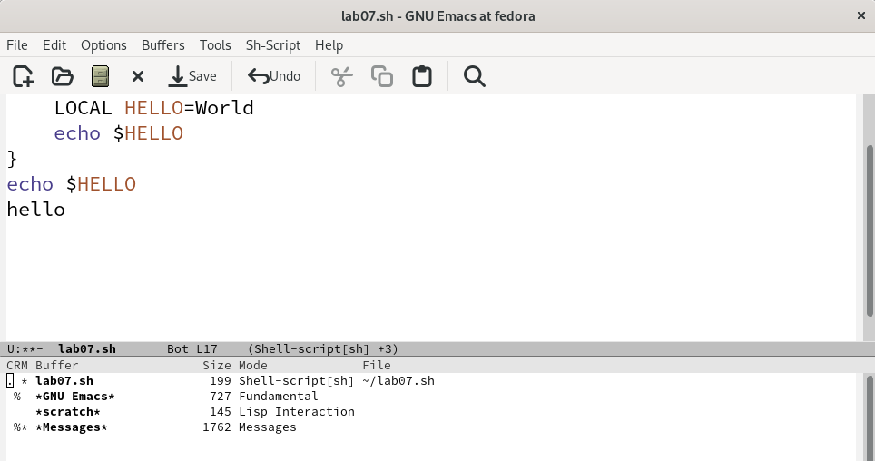

Список активных буферов

## 7.2. Переместитесь во вновь открытое окно (C-x) o со списком открытых буферов и переключитесь на другой буфер.

[figure not shown]

## 7.3. Закройте это окно (C-x 0). 7.4. Теперь вновь переключайтесь между буферами, но уже без вывода их списка на экран (C-x b).

# 8. Управление окнами.

## 8.1. Поделите фрейм на 4 части: разделите фрейм на два окна по вертикали (C-x 3), а затем каждое из этих окон на две части по горизонтали (C-x 2). 8.2. В каждом из четырёх созданных окон откройте новый буфер (файл) и введите несколько строк текста.

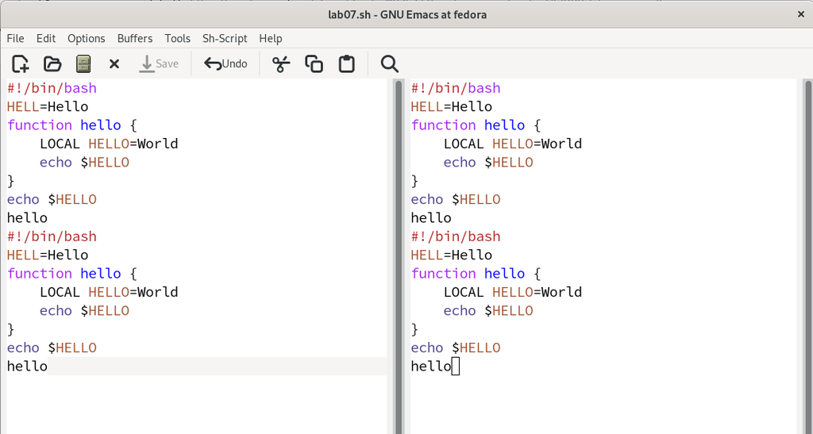

2 окна

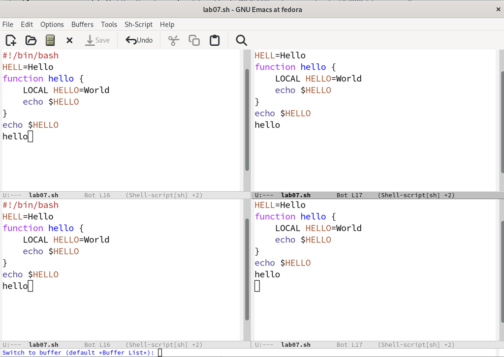

4 окна